# Prediction Assignment Writeup

huangli

2016-04-2

## Introduction

Using devices such as Jawbone Up, Nike FuelBand, and Fitbit it is now possible to collect a large amount of data about personal activity relatively inexpensively. These type of devices are part of the quantified self movement. In this project, we will use data from accelerometers on the belt, forearm, arm, and dumbell of 6 participants. They were asked to perform barbell lifts correctly and incorrectly in 5 different ways.

## Getting and cleaning data

### Getting data

```r
trainUrl <-"https://d396qusza40orc.cloudfront.net/predmachlearn/pml-training.csv"
testUrl <- "https://d396qusza40orc.cloudfront.net/predmachlearn/pml-testing.csv"
trainFile <- "./data/pml-training.csv"
testFile  <- "./data/pml-testing.csv"
if (!file.exists("./data")) {
  dir.create("./data")
}
if (!file.exists(trainFile)) {
  download.file(trainUrl, destfile=trainFile, method="curl")
}
if (!file.exists(testFile)) {
  download.file(testUrl, destfile=testFile, method="curl")
}

# read the data
trainRaw <- read.csv("./data/pml-training.csv")
testRaw <- read.csv("./data/pml-testing.csv")
```

### Cleaning the data

The first 7 columns are useless for prediction, so I remove them.

The NA percentages are 97.93% in 67 variables, for the left 86 variables they are all complete cases. So we will remove all the 67 variables.

```
##
##                0 97.9308938946081
##               86               67
```

## Data Modeling

We fit a predictive model for activity recognition using Random Forest algorithm because it automatically selects important variables and is robust to correlated covariates & outliers in general. We will use 5-fold cross validation when applying the algorithm.

```r
controlRf <- trainControl(method="cv", 5)
modelRf <- train(classe ~ ., data=trainData, method="rf", trControl=controlRf, ntree=250)
modelRf
```

```
## Random Forest
##
## 13737 samples
##    52 predictor
##     5 classes: 'A', 'B', 'C', 'D', 'E'
##
## No pre-processing
## Resampling: Cross-Validated (5 fold)
##
## Summary of sample sizes: 10989, 10990, 10990, 10989, 10990
##
## Resampling results across tuning parameters:
##
##   mtry  Accuracy   Kappa      Accuracy SD  Kappa SD
##    2    0.9912645  0.9889491  0.001627875  0.002059280
##   27    0.9901726  0.9875683  0.002183506  0.002762248
##   52    0.9856591  0.9818570  0.001327868  0.001681098
##
## Accuracy was used to select the optimal model using  the largest value.
## The final value used for the model was mtry = 2.
```

Then, we estimate the performance of the model on the validation data set.

```r
predictRf <- predict(modelRf, testData)
confusionMatrix(testData$classe, predictRf)
```

```
## Confusion Matrix and Statistics
##
##           Reference
## Prediction    A    B    C    D    E
##          A 1673    1    0    0    0
##          B   14 1119    6    0    0
##          C    0   18 1004    4    0
##          D    0    0   25  939    0
##          E    0    0    0    3 1079
##
## Overall Statistics
##
##                Accuracy : 0.9879
##                  95% CI : (0.9848, 0.9906)
##     No Information Rate : 0.2867
##     P-Value [Acc > NIR] : < 2.2e-16
##
##                   Kappa : 0.9847
##  Mcnemar's Test P-Value : NA
##
## Statistics by Class:
##
##                      Class: A Class: B Class: C Class: D Class: E
## Sensitivity            0.9917   0.9833   0.9700   0.9926   1.0000
## Specificity            0.9998   0.9958   0.9955   0.9949   0.9994
## Pos Pred Value         0.9994   0.9824   0.9786   0.9741   0.9972
## Neg Pred Value         0.9967   0.9960   0.9936   0.9986   1.0000
## Prevalence             0.2867   0.1934   0.1759   0.1607   0.1833
## Detection Rate         0.2843   0.1901   0.1706   0.1596   0.1833
## Detection Prevalence   0.2845   0.1935   0.1743   0.1638   0.1839
## Balanced Accuracy      0.9957   0.9895   0.9828   0.9938   0.9997
```

```r
accuracy <- postResample(predictRf, testData$classe)
accuracy
```

```
##  Accuracy     Kappa
## 0.9879354 0.9847348
```

## Predicting for Test Data Set

we apply the model to the original testing data set downloaded from the data source.

```r
result <- predict(modelRf, test[, 1:52])
result
```

```
##  [1] B A B A A E D B A A B C B A E E A B B B
## Levels: A B C D E
```

## Appenix: Figures

### Tree Visualization

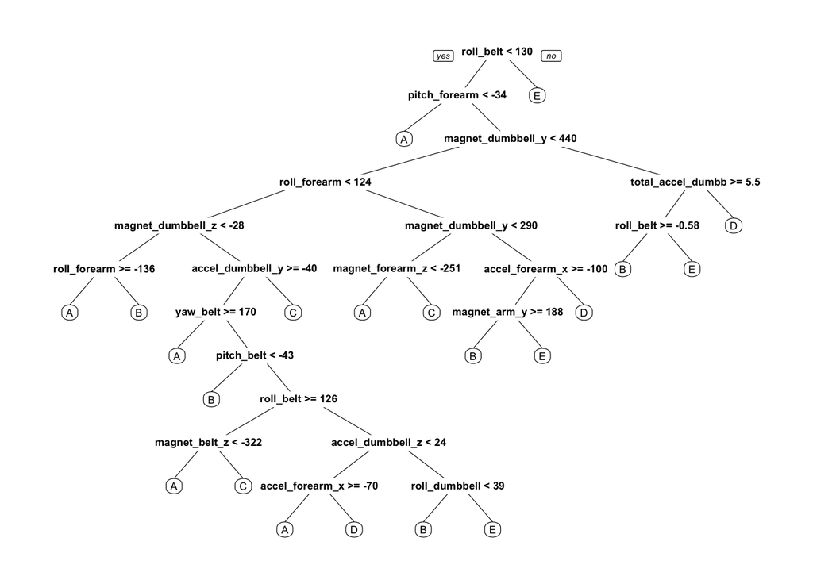

```r
treeModel <- rpart(classe ~ ., data=trainData, method="class")
prp(treeModel) # fast plot
```